# Reproducible Research: Peer Assessment 1

Benny96

This markdown template will contain the answer to the PA_1 exercise.

## Loading and preprocessing the data

0- Load the required packages for the analysis (previous installation of them is expected):

```r
library(data.table); library(xtable); library(timeDate)
```

1- Read the CSV file downloaded via the Assignment Statement:

```r
file <- "activity.zip"
unzip(file, exdir=".")
data <- read.csv("./activity.csv", header = TRUE)
```

2- Check the first 6 rows of the data:

```r
head(data)
```

```
##   steps       date interval
## 1    NA 2012-10-01        0
## 2    NA 2012-10-01        5
## 3    NA 2012-10-01       10
## 4    NA 2012-10-01       15
## 5    NA 2012-10-01       20
## 6    NA 2012-10-01       25
```

## What is mean total number of steps taken per day?

0- Obtain the total number of steps taken per day. `aggregate()` will create subsets of the data, considering the amount of steps taken per day.

```r
stepsDay <- aggregate(steps~date,data,sum)
head(stepsDay)
```

```
##         date steps
## 1 2012-10-02   126
## 2 2012-10-03 11352
## 3 2012-10-04 12116
## 4 2012-10-05 13294
## 5 2012-10-06 15420
## 6 2012-10-07 11015
```

1- Make a histogram of the total number of steps taken each day.

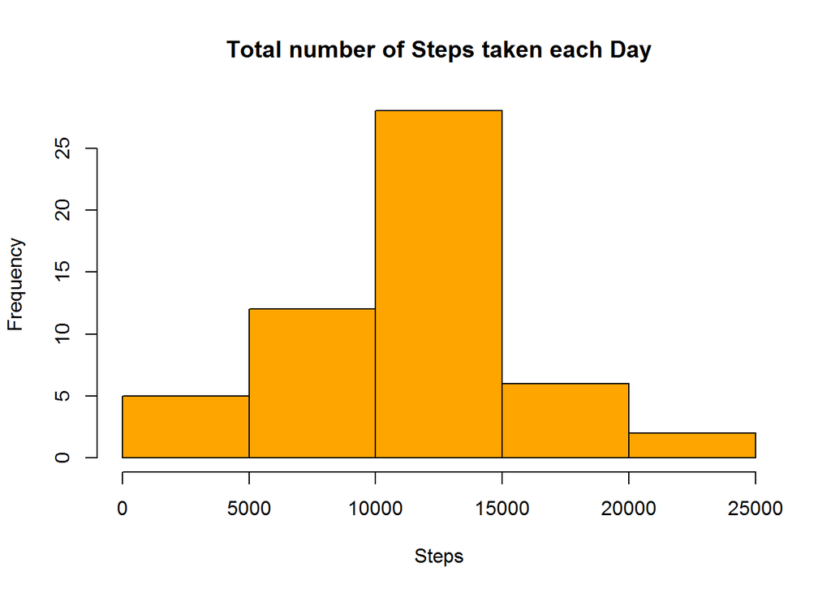

```r
hist(stepsDay$steps, col = "orange", xlab = "Steps", main = "Total number of Steps taken each Day")
```

2- Calculate and report the **mean** and **median** total number of steps taken per day

```r
mean0 <- mean(stepsDay$steps)
mean0
```

```
## [1] 10766.19
```

```r
median0 <- median(stepsDay$steps)
median0
```

```
## [1] 10765
```

## What is the average daily activity pattern?

0- Subset the total number of steps by 5-min intervals to obtain the average from it.

```r
stepsInterval <- aggregate(steps~interval,data,mean)
head(stepsInterval)
```

```
##   interval     steps
## 1        0 1.7169811
## 2        5 0.3396226
## 3       10 0.1320755
## 4       15 0.1509434
## 5       20 0.0754717
## 6       25 2.0943396
```

1- Make a time series plot (i.e. `type = "l"`) of the 5-minute interval (x-axis) and the average number of steps taken, averaged across all days (y-axis)

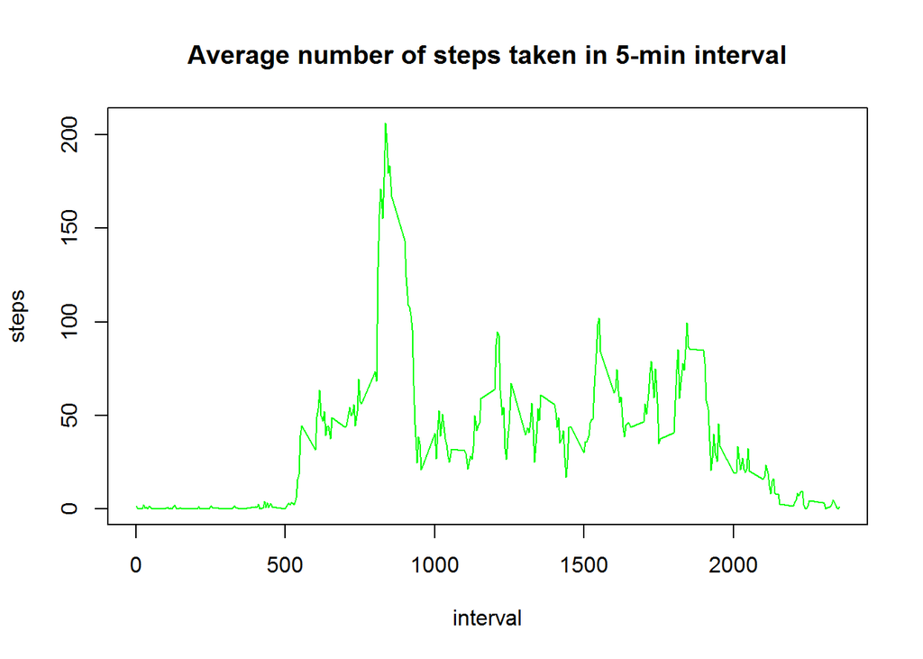

```r
with(stepsInterval, plot(interval, steps , type="l", main="Average number of steps taken in 5-min interval" , col = "green"))
```

```r
max <- max(stepsInterval$steps)
max
```

```
## [1] 206.1698
```

## Imputing missing values

1- Calculate and report the total number of missing values in the dataset (i.e. the total number of rows with NAs)

```r
colSums(is.na(data))
```

```
##    steps     date interval
##     2304        0        0
```

2- Devise a strategy for filling in all of the missing values in the dataset. The strategy does not need to be sophisticated. For example, you could use the mean/median for that day, or the mean for that 5-minute interval, etc.

2.1. Create a new column “avgSteps” which contains the average steps in each interval.

```r
data$avgSteps <- stepsInterval$steps
head(data)
```

```
##   steps       date interval  avgSteps
## 1    NA 2012-10-01        0 1.7169811
## 2    NA 2012-10-01        5 0.3396226
## 3    NA 2012-10-01       10 0.1320755
## 4    NA 2012-10-01       15 0.1509434
## 5    NA 2012-10-01       20 0.0754717
## 6    NA 2012-10-01       25 2.0943396
```

2.2. Fill in the missing data.

```r
data$steps[is.na(data$steps)] <- data$avgSteps
head(data)
```

```
##       steps       date interval  avgSteps
## 1 1.7169811 2012-10-01        0 1.7169811
## 2 0.3396226 2012-10-01        5 0.3396226
## 3 0.1320755 2012-10-01       10 0.1320755
## 4 0.1509434 2012-10-01       15 0.1509434
## 5 0.0754717 2012-10-01       20 0.0754717
## 6 2.0943396 2012-10-01       25 2.0943396
```

3.1. Create a new dataset that is equal to the original dataset but with the missing data filled in.

```r
newdata <- data
head(newdata)
```

```
##       steps       date interval  avgSteps
## 1 1.7169811 2012-10-01        0 1.7169811
## 2 0.3396226 2012-10-01        5 0.3396226
## 3 0.1320755 2012-10-01       10 0.1320755
## 4 0.1509434 2012-10-01       15 0.1509434
## 5 0.0754717 2012-10-01       20 0.0754717
## 6 2.0943396 2012-10-01       25 2.0943396
```

3.2. Subset the new modified data set to obtain the total number of steps per day.

```r
moddata <- aggregate(steps~date, newdata, sum)
head(moddata)
```

```
##         date    steps
## 1 2012-10-01 10766.19
## 2 2012-10-02   126.00
## 3 2012-10-03 11352.00
## 4 2012-10-04 12116.00
## 5 2012-10-05 13294.00
## 6 2012-10-06 15420.00
```

4.1. Make a histogram of the total number of steps taken each day.

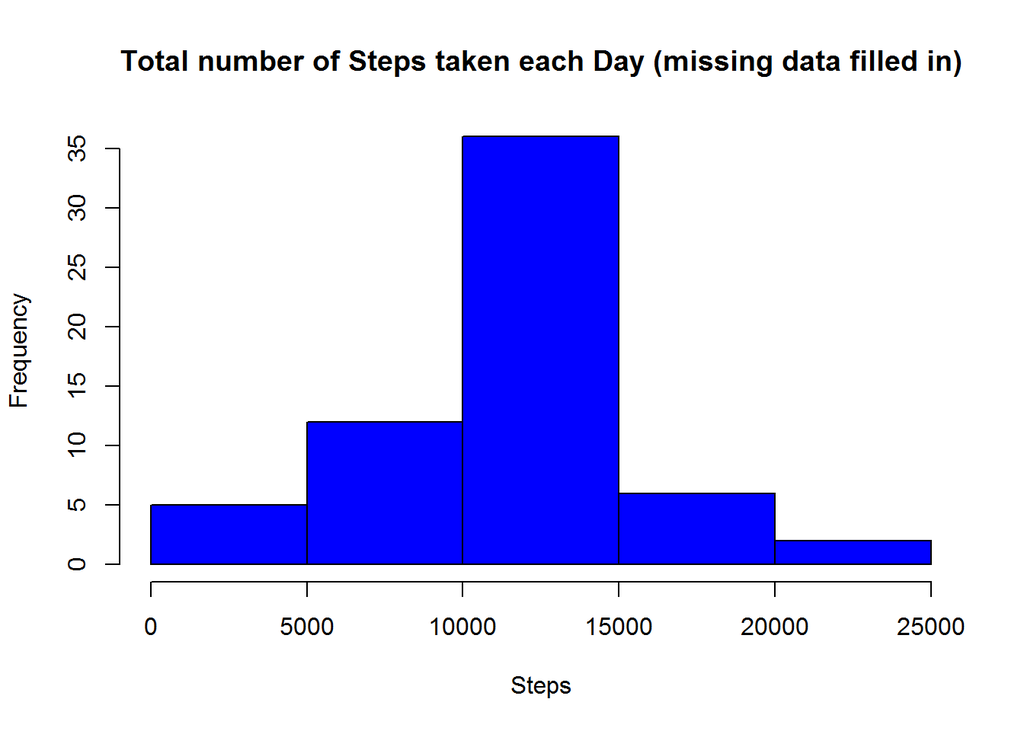

```r
hist(moddata$steps, col = "blue", xlab = "Steps"
     , main = "Total number of Steps taken each Day (missing data filled in)")
```

4.2. Calculate and report the **mean** and **median** total number of steps taken per day.

```r
mean1 <- mean(moddata$steps)
mean1
```

```
## [1] 10766.19
```

```r
median1 <- median(moddata$steps)
median1
```

```
## [1] 10766.19
```

4.3. Calculate the differences of the **mean** and **median** between the first and second part.

```r
mean1 - mean0
```

```
## [1] 0
```

```r
median1 - median0
```

```
## [1] 1.188679
```

## Are there differences in activity patterns between weekdays and weekends?

1- Create a new factor variable in the dataset with two levels – “weekday” and “weekend” indicating whether a given date is a weekday or weekend day.

*Note*: Here I decided to use the `isWeekday()` function from the timeDate package.

1.1. Add a new column, adding a flag checking whether the date is a weekday or weekend.

```r
newdata$Weekday <- isWeekday(newdata$date)
head(newdata)
```

```
##       steps       date interval  avgSteps Weekday
## 1 1.7169811 2012-10-01        0 1.7169811    TRUE
## 2 0.3396226 2012-10-01        5 0.3396226    TRUE
## 3 0.1320755 2012-10-01       10 0.1320755    TRUE
## 4 0.1509434 2012-10-01       15 0.1509434    TRUE
## 5 0.0754717 2012-10-01       20 0.0754717    TRUE
## 6 2.0943396 2012-10-01       25 2.0943396    TRUE
```

1.2. Make the respective calculations for each level.

Weekday:

```r
weekday <- subset(newdata, newdata$Weekday == "TRUE")
weekdayMean <- aggregate(steps ~ interval, data = weekday, mean)
head(weekdayMean)
```

```
##   interval      steps
## 1        0 2.25115304
## 2        5 0.44528302
## 3       10 0.17316562
## 4       15 0.19790356
## 5       20 0.09895178
## 6       25 1.59035639
```

Weekend:

```r
weekend <- subset(newdata, newdata$Weekday == "FALSE")
weekendMean <- aggregate(steps ~ interval, data = weekend, mean)
head(weekendMean)
```

```
##   interval       steps
## 1        0 0.214622642
## 2        5 0.042452830
## 3       10 0.016509434
## 4       15 0.018867925
## 5       20 0.009433962
## 6       25 3.511792453
```

2- Make a panel plot containing a time series plot (i.e. `type = "l"`) of the 5-minute interval (x-axis) and the average number of steps taken, averaged across all weekday days or weekend days (y-axis).

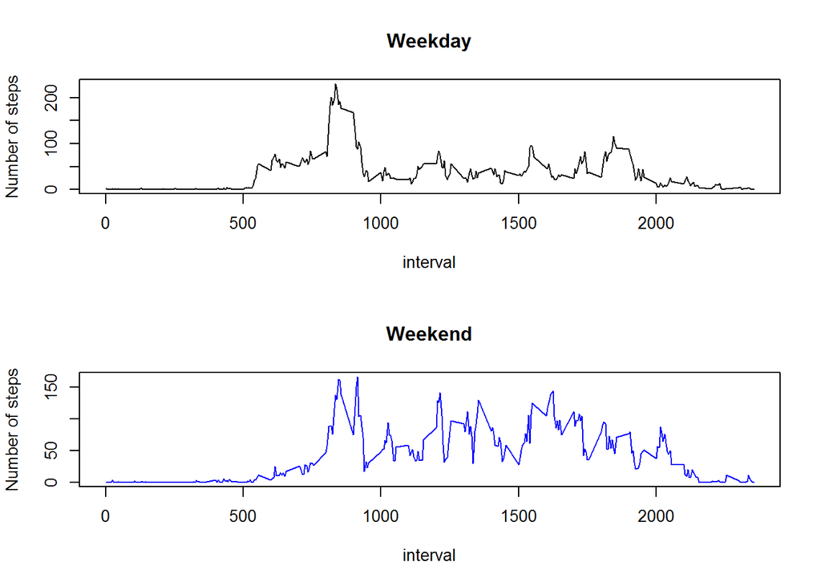

```r
layout(matrix(c(1,1,2,2), 2, 2, byrow = TRUE))
plot(weekdayMean$interval, weekdayMean$steps, xlab = "interval", ylab = "Number of steps", main ="Weekday", col ="black", type="l")

plot(weekendMean$interval, weekendMean$steps, xlab = "interval", ylab = "Number of steps", main ="Weekend", col ="blue", type="l")
```

**Conclusion:**

So, as we can see, the most remarkable difference between Weekdays and Weekends appear in the afternoon’s intervals. At that time, the amount of steps done is slightly higher (watch out the y-axis units!) than the measures obtained in weekdays.